# PCFL 2021: Week 7 wrap-up

### Last week’s games

| Away | Away points | Home | Home points |
| --- | --- | --- | --- |
| The G.O.A.T. | 80.34 | Middle Earth Hangry Hobbits | 111.76 |
| Athens Team Sasquatch | 126.93 | The Sophomores TSoph | 117.76 |
| Jumpin’ Jaheims | 100.70 | Southern Sharks | 144.54 |
| Pigskin on the Gridiron | 120.04 | Georgia Peanuts | 108.89 |
| Captain Clairvoyant | 118.24 | KC Gophers | 87.44 |

Well, the New Orleans defense came through for Robbie, and so Team Sasquatch came away with the W against the Sophomores. The Southern Sharks had possibly their most impressive week of the season, putting up 144 points (this week’s top score) against The Jumpin’ Jaheims. The Hangry Hobbits best the GOAT, whose offense continues to struggle, and Captain Clairvoyant best the Gophers. Lastly, Richard handed me my second straight loss.

Last week’s spread went 3-2: It got Scott, Sarah, and Brian right as winners, but missed on Richard and Robbie.

Also, as a Bears fan, I hope all of you who won on the back of Tampa’s players this week feel a sense of gratitude.

#### Best performing players

Here’s last week’s **10 best performing players.**

| Player | Points | Team |
| --- | --- | --- |
| Cooper Kupp | 32.60 | Pigskin on the Gridiron |
| Ja’Marr Chase | 31.10 | Southern Sharks |
| Alvin Kamara | 28.90 | Jumpin’ Jaheims |
| Mike Evans | 28.60 | Pigskin on the Gridiron |
| Matthew Stafford | 27.16 | Middle Earth Hangry Hobbits |
| Joe Burrow | 26.64 | Pigskin on the Gridiron |
| Tua Tagovailoa | 26.54 | Georgia Peanuts |
| D’Andre Swift | 25.40 | Captain Clairvoyant |
| Aaron Rodgers | 24.66 | The Sophomores TSoph |
| Tom Brady | 24.44 | Captain Clairvoyant |

Cooper Kupp is having a nice season, and Ja’Marr Chase had a breakout week for the Sharks.

#### Best addition and top bench

There were 19 players added last week. Which was the **best new addition**?

| Date added | Name | Points | Team |
| --- | --- | --- | --- |
| 2021-10-20 | Tua Tagovailoa | 26.54 | Georgia Peanuts |
| 2021-10-20 | D’Ernest Johnson | 23.80 | Athens Team Sasquatch |
| 2021-10-20 | Giants D/ST | 17.00 | Southern Sharks |
| 2021-10-22 | Robert Tonyan | 14.30 | KC Gophers |
| 2021-10-24 | Dante Pettis | 13.04 | Athens Team Sasquatch |
| 2021-10-20 | Randy Bullock | 11.00 | Southern Sharks |
| 2021-10-20 | Packers D/ST | 10.00 | Captain Clairvoyant |
| 2021-10-20 | Saints D/ST | 10.00 | Athens Team Sasquatch |
| 2021-10-20 | Hunter Henry | 9.30 | Southern Sharks |
| 2021-10-20 | Daniel Carlson | 9.00 | Georgia Peanuts |
| 2021-10-20 | A.J. Green | 8.10 | Captain Clairvoyant |
| 2021-10-22 | Ricky Seals-Jones | 8.10 | Jumpin’ Jaheims |
| 2021-10-20 | J.D. McKissic | 7.60 | Georgia Peanuts |
| 2021-10-24 | Darnell Mooney | 4.90 | Georgia Peanuts |
| 2021-10-23 | Miles Sanders | 3.20 | Jumpin’ Jaheims |
| 2021-10-20 | Rams D/ST | 3.00 | Georgia Peanuts |
| 2021-10-22 | Sam Darnold | 2.44 | The G.O.A.T. |
| 2021-10-21 | Tyler Bass | 0.00 | Athens Team Sasquatch |
| 2021-10-22 | Cowboys D/ST | 0.00 | Athens Team Sasquatch |

The bye week brings a many transactions! Tua was a nice fill-in for me this week with Justin Herbert on bye, and D’Ernest Johnson did a nice job filling in for my injured Cleveland backs. The Giants Defense also had a very nice week, but Sam Darnold and the Panthers are good for that.

Who won the **best scoring bench** award last week?

| Team | Points |
| --- | --- |
| Athens Team Sasquatch | 97.53 |
| The Sophomores TSoph | 72.82 |
| Pigskin on the Gridiron | 70.92 |
| Middle Earth Hangry Hobbits | 70.40 |
| Captain Clairvoyant | 55.49 |
| Southern Sharks | 54.30 |
| Jumpin’ Jaheims | 48.90 |
| KC Gophers | 45.38 |
| The G.O.A.T. | 20.50 |
| Georgia Peanuts | 15.10 |

### League standings and season stats

Here’s a look at the current standings.

| Team | Division | W | L | Points scored | Points allowed | Points rank | Playoff rank |
| --- | --- | --- | --- | --- | --- | --- | --- |
| The Sophomores TSoph | Hot Dish | 5 | 2 | 863.40 | 783.03 | 2 | 1 |
| Pigskin on the Gridiron | Grits | 5 | 2 | 831.36 | 799.84 | 4 | 2 |
| Captain Clairvoyant | Grits | 5 | 2 | 811.30 | 761.43 | 6 | 3 |
| Athens Team Sasquatch | Grits | 4 | 3 | 879.23 | 866.90 | 1 | 4 |
| Georgia Peanuts | Hot Dish | 4 | 3 | 768.33 | 763.77 | 8 | 5 |
| Middle Earth Hangry Hobbits | Hot Dish | 3 | 4 | 839.04 | 780.24 | 3 | 6 |
| Southern Sharks | Hot Dish | 3 | 4 | 827.34 | 847.64 | 5 | 7 |
| Jumpin’ Jaheims | Grits | 3 | 4 | 772.55 | 822.47 | 7 | 8 |
| KC Gophers | Hot Dish | 2 | 5 | 714.32 | 781.98 | 9 | 9 |
| The G.O.A.T. | Grits | 1 | 6 | 659.56 | 759.13 | 10 | 10 |

Here’s a list of the **top five scoring performances** so far this season.

| Team | Week | Points scored | Result |
| --- | --- | --- | --- |
| Georgia Peanuts | 5 | 158.97 | W |
| The Sophomores TSoph | 4 | 158.62 | W |
| Athens Team Sasquatch | 5 | 149.80 | W |
| The G.O.A.T. | 4 | 149.52 | W |
| KC Gophers | 1 | 149.28 | W |

No new entries this week.

### Here’s a look at the **points trendline** for each team.

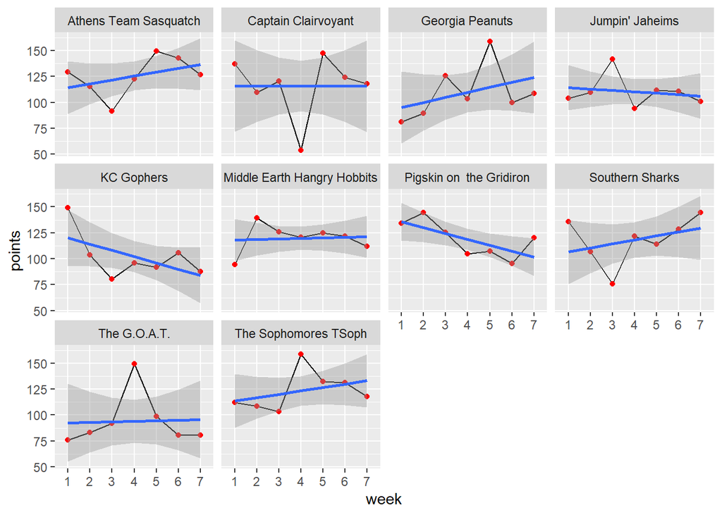

I mentioned Team Sasquatch, but the Sharks have also been showing some good improvement the last few weeks.

### If the season ended today…

Our playoff teams would be Erin/Trav, Richard, Brian, and Robbie. Our last place finisher would be Jacob.Just about halfway through the season, and things are starting to settle in.

### Next week’s preview

| Away team | Last 3 wks avg (away) | Home team | Last 3 wks avg (home) | Line |
| --- | --- | --- | --- | --- |
| The Sophomores TSoph | 127.01 | The G.O.A.T. | 86.41 | The Sophomores TSoph (+40.6) |
| Southern Sharks | 129.05 | Athens Team Sasquatch | 139.88 | Athens Team Sasquatch (+10.83) |
| Georgia Peanuts | 122.64 | Jumpin’ Jaheims | 107.65 | Georgia Peanuts (+14.99) |
| KC Gophers | 95.00 | Pigskin on the Gridiron | 107.53 | Pigskin on the Gridiron (+12.53) |
| Middle Earth Hangry Hobbits | 119.53 | Captain Clairvoyant | 129.99 | Captain Clairvoyant (+10.46) |

Sarah’s Sharks have been doing better as of late, but Sasquatch has still been a touchdown and field goal better over the last three weeks, so he’s favored in their game of the week matchup. The GOAT tries for the upset against the Sophomores, and I try to get back in the win column against Evan. It’s been tough going for Christine since her week 1 victory, but I’m rooting for her against Richard this week. Lastly, Brian and Scott face off, with Brian also favored by about 10.

Good luck, y’all! (And remember to check your byes!)